# Generics and Alternatives: Experiment 3

17-02-2020

As a quick reminder: in experiment 3, participants provide assertability judgements for two conditions: a contrast condition (“CON”) where the feature is absent in the contrast picture, and a no contrast condition (“NC”) where the feature is present in the same proportion in both pictures. Participants are assigned randomly to one of four possible proportions: 14, 17, 20 and 23 items present the feature out of 25. They judge one item (frogs, bettles or spiders) in each condition and they also complete an attention check where they judge an obviously false statement. Assertability responses are provided on a 0-5 scale, which is mapped onto the contingency scale such that 0 in assertability corresponds to -1 on the contingency scale, 2.5 corresponds to 0, and 5 corresponds to +1.

Total number of collected responses:

```
## [1] 408
```

# 1. Data exploration and visualization

Participants who gave an assertability rating stricly higher than 1.5 to the check, as well as those who gave an assertability rating of 0 in both conditions were excluded from the sample. The difference score between responses in the CON and NC conditions is used to classify participants according to three response patterns: CON > NC, CON ≈ NC, CON < NC.

Number of participants included in the sample:

```r
(Participants <- nrow(cleaned_data))
```

```
## [1] 376
```

Barplot of the three response patterns:

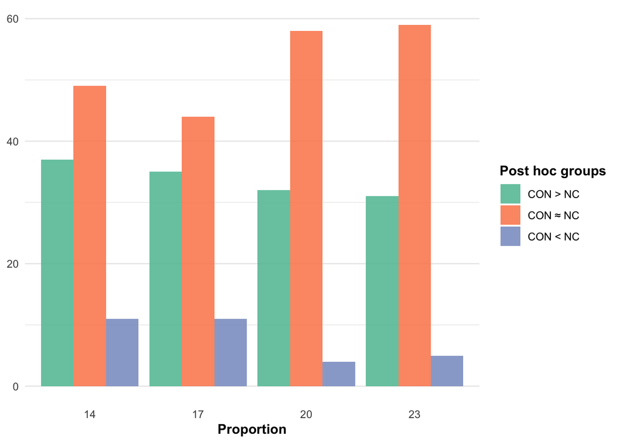

Because the prevalence of the CON ≈ NC is relatively surprising, we can investigate a few possible explanations.

The data was collected in two sessions separated in time: could there have been a decline in participant quality?

=> The three patterns appear in both sessions.

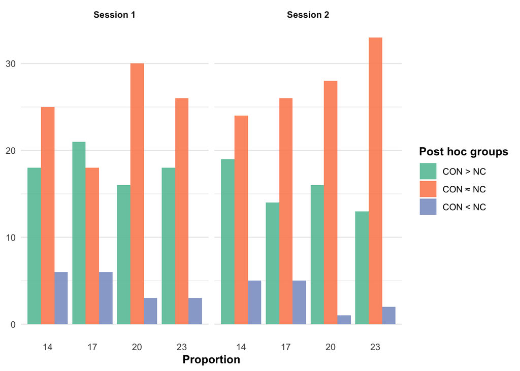

Did participants with this response pattern spend less time on the survey?

=> There is no obvious relationship between response time and response pattern.

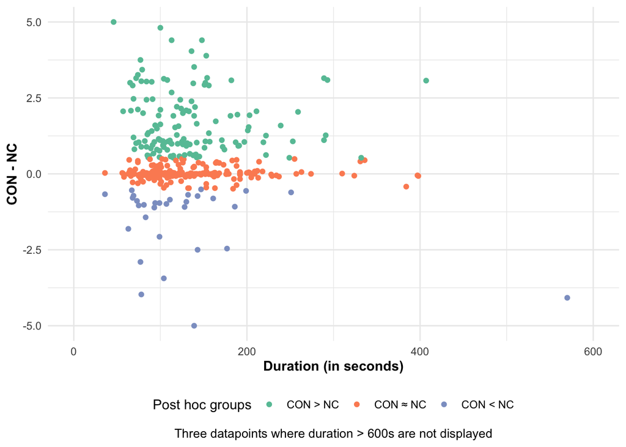

Finally, we can look at how the responses from participants in each group were distributed across the scale.

=> Participants with the CON ≈ NC response pattern do not seem to favor a specific part of the scale.

=> This response pattern also appears reliably for all proportions.

Note also that sometimes participants with this response pattern are inside the shaded area (which represents the theoretical expectations with some allowance for error).

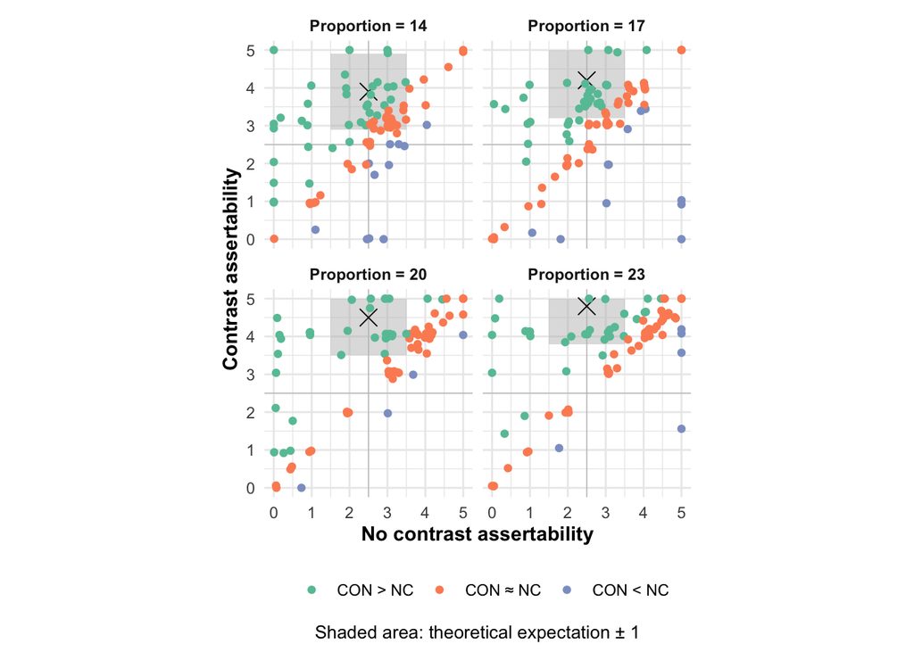

In order to further explore the data, we can use a raincloud plot to compare responses for each condition across different proportions. From visual inspection, it looks like median responses in the Contrast condition tend to be higher than in the No Contrast condition, and it also looks like there is a positive trend along Proportion. However, the plot also shows that there is a lot of spread in the data.

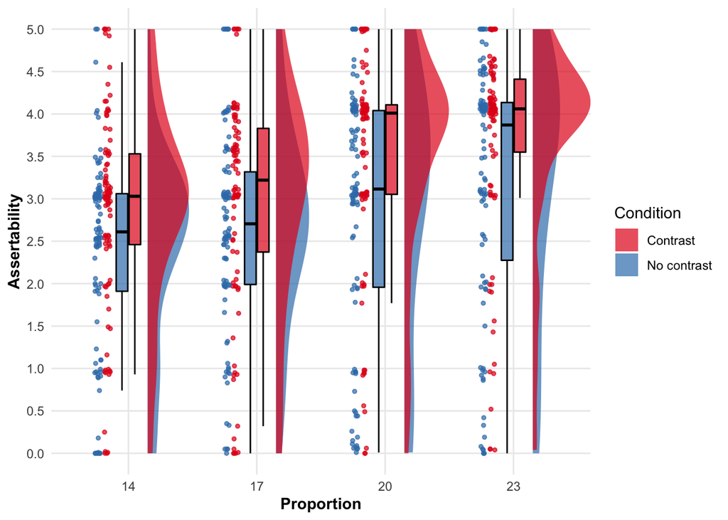

Finally, one last sanity check: comparing responses for the three different items for each condition and proportion. There are differences between items but nothing that looks systematic.

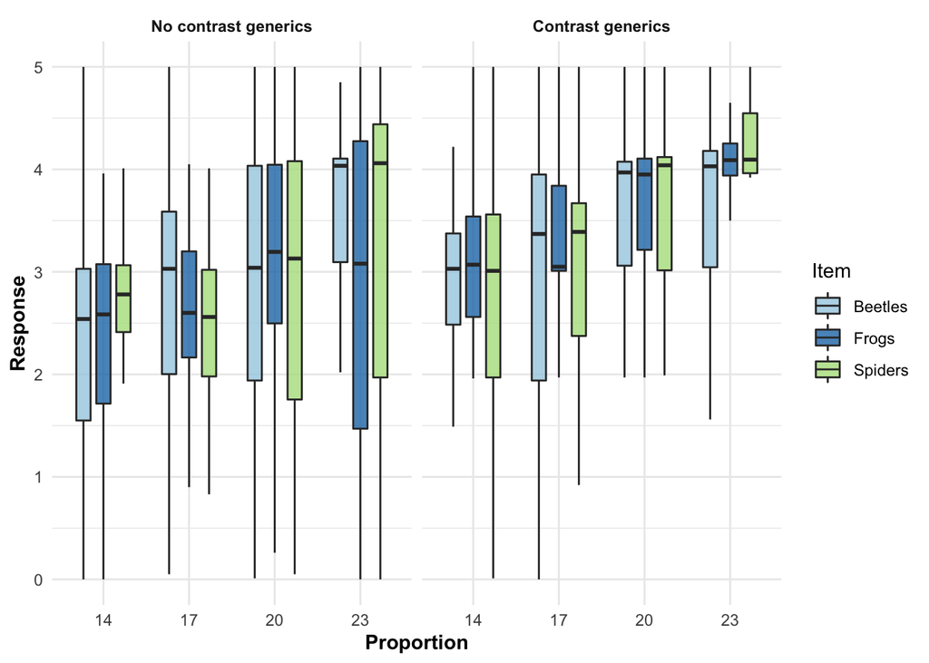

# 2. Data analysis

We can now move on to analyzing the data. One possibility is to analyze the data using the following linear mixed model:

```r
int_post_formula <- "Response ~ 0 + Condition * mo(Proportion) * Diff + (1 |Subject) + (1 |Item)"
```

We seek to predict assertability responses on the basis of the interaction between Condition and Proportion and Response pattern (“Diff”). #’ Because Proportion is a discrete and ordered variable, we define it as an ordinal (monotonic) parameter. For simplicity, we only fit a random intercept per Subject and per Item and do not fit any random slopes.

Because we use a Bayesian approach, the first step is to define sensible priors (ie priors that place a very low probability on impossible values given the data structure). We define the priors as follows:

```r
int_post_prior <- c(

  set_prior("normal(2.5, 0.83)", class = "b", coef = "ConditionNC"),
  set_prior("normal(2.5, 0.83)", class = "b", coef = "ConditionCON"),
  set_prior("normal(0, 0.25)", class = "b", coef = "Post_conditionId"),
  set_prior("normal(0, 0.25)", class = "b", coef = "Post_conditionNeg"),

  set_prior("normal(0, 0.25)", class = "b", coef = "moProportion"),

  set_prior("normal(0, 0.25)", class = "b", coef = "ConditionCON:Post_conditionId"),
  set_prior("normal(0, 0.25)", class = "b", coef = "ConditionCON:Post_conditionNeg"),
  set_prior("normal(0, 0.25)", class = "b", coef = "moProportion:ConditionCON"),
  set_prior("normal(0, 0.25)", class = "b", coef = "moProportion:Post_conditionId"),
  set_prior("normal(0, 0.25)", class = "b", coef = "moProportion:Post_conditionNeg"),
  set_prior("normal(0, 0.25)", class = "b", coef = "moProportion:ConditionCON:Post_conditionId"),
  set_prior("normal(0, 0.25)", class = "b", coef = "moProportion:ConditionCON:Post_conditionNeg"),


  set_prior("normal(1, 3)", class = "sd"),
  set_prior("normal(1, 3)", class = "sigma")
)
```

We next perform a prior predictive check, where we sample from our defined priors and observed whether they have sensible consequences on the data.

```r
# Prior predictive checks
int_post_prior_fit <- brm(data = gen_alts_data,
                          formula = int_post_formula,
                          prior = int_post_prior,
                          sample_prior = "only",
                          iter = 5000, warmup = 1500, chains = 4, cores = 4,
                          control = list(adapt_delta = .90),
                          file = "int_post_prior_fit")
```

The following plot displays the 95% most likely parameter estimates for the simulated data that was generated on the basis of our priors. It can also serve as a graphical representation of the priors.  
These are fairly wide priors that simply indicate that values outside the 0-5 range are very unlikely. In this case, because we already have the data available, we can overlay it to further assess our priors.

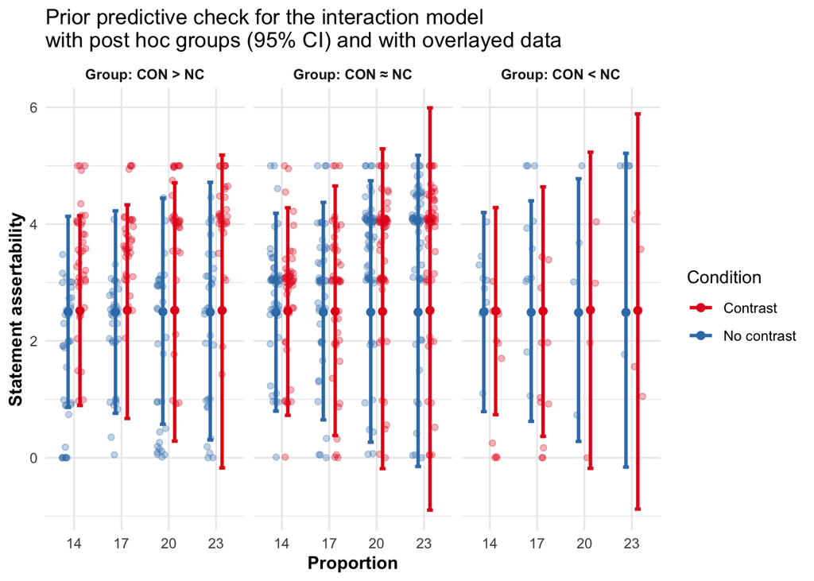

Next, if we are satisfied with our priors, we fit the model to the data.

```r
int_post_fit <- brm(data = gen_alts_data,
                    formula = int_post_formula,
                    prior = int_post_prior,
                    iter = 5000, warmup = 1500, chains = 4, cores = 4,
                    control = list(adapt_delta = .90),
                    file = "int_post_fit")
```

The model provides the following parameter estimates. For now, we only focus on the Population-Level Effects. We can also disregard the estimates for the “CON < NC” response pattern given that there was significantly less data in that group.

```r
summary(int_post_fit)
```

```
##  Family: gaussian
##   Links: mu = identity; sigma = identity
## Formula: Response ~ 0 + Condition * mo(Proportion) * Post_condition + (1 | Subject) + (1 | Item)
##    Data: gen_alts_data (Number of observations: 752)
## Samples: 4 chains, each with iter = 5000; warmup = 1500; thin = 1;
##          total post-warmup samples = 14000
##
## Group-Level Effects:
## ~Item (Number of levels: 3)
##               Estimate Est.Error l-95% CI u-95% CI Rhat Bulk_ESS Tail_ESS
## sd(Intercept)     0.13      0.21     0.00     0.76 1.00     1662      942
##
## ~Subject (Number of levels: 376)
##               Estimate Est.Error l-95% CI u-95% CI Rhat Bulk_ESS Tail_ESS
## sd(Intercept)     1.05      0.05     0.97     1.14 1.00     2602     5284
##
## Population-Level Effects:
##                                             Estimate Est.Error l-95% CI
## ConditionNC                                     2.13      0.16     1.82
## ConditionCON                                    3.27      0.17     2.93
## Post_conditionId                                0.44      0.15     0.13
## Post_conditionNeg                               0.22      0.20    -0.18
## ConditionCON:Post_conditionId                  -0.95      0.13    -1.20
## ConditionCON:Post_conditionNeg                 -1.46      0.18    -1.81
## moProportion                                    0.04      0.07    -0.09
## moProportion:ConditionCON                       0.23      0.05     0.14
## moProportion:Post_conditionId                   0.29      0.08     0.13
## moProportion:Post_conditionNeg                  0.44      0.14     0.18
## moProportion:ConditionCON:Post_conditionId     -0.29      0.06    -0.41
## moProportion:ConditionCON:Post_conditionNeg    -0.58      0.09    -0.76
##                                             u-95% CI Rhat Bulk_ESS Tail_ESS
## ConditionNC                                     2.45 1.00     1272      946
## ConditionCON                                    3.61 1.00     1411      999
## Post_conditionId                                0.73 1.00     2625     4112
## Post_conditionNeg                               0.62 1.00     4711     3354
## ConditionCON:Post_conditionId                  -0.69 1.00     6120     8642
## ConditionCON:Post_conditionNeg                 -1.11 1.00     6662     4234
## moProportion                                    0.18 1.00     1343     2751
## moProportion:ConditionCON                       0.33 1.00     4336     1678
## moProportion:Post_conditionId                   0.44 1.00     2180     4724
```

[output cut: 36 more lines]

```
## moProportion:Post_conditionNeg1[3]                  0.69 1.00     6713     7792
## moProportion:ConditionCON:Post_conditionId1[1]      0.81 1.00     6897     5624
## moProportion:ConditionCON:Post_conditionId1[2]      0.78 1.00     7378     8079
## moProportion:ConditionCON:Post_conditionId1[3]      0.45 1.00    10850     8647
## moProportion:ConditionCON:Post_conditionNeg1[1]     0.97 1.00    10160     5254
## moProportion:ConditionCON:Post_conditionNeg1[2]     0.23 1.00     8800     2967
## moProportion:ConditionCON:Post_conditionNeg1[3]     0.31 1.00     8352     5460
##
## Family Specific Parameters:
##       Estimate Est.Error l-95% CI u-95% CI Rhat Bulk_ESS Tail_ESS
## sigma     0.54      0.02     0.50     0.58 1.00     3580     7804
##
## Samples were drawn using sampling(NUTS). For each parameter, Bulk_ESS
## and Tail_ESS are effective sample size measures, and Rhat is the potential
## scale reduction factor on split chains (at convergence, Rhat = 1).
```

We start by comparing the estimates for the means of the two conditions (Contrast and No Contrast) to see if the difference between the two is larger than 0. When Proportion = 14, for the “CON > NC” group, the mean difference between the two conditions is estimated at 1.14 on the assertability scale, with the lower bound also above zero, so Items in the Contrast condition received reliably higher assertability ratings.

For the “CON ≈ NC” group, we find a small positive difference estimated at 0.18, but with a lower bound that goes down to zero, which means that Items in the Contrast condition did not receive reliable higher assertability ratings than in the No Contrast condition.

```r
posterior_int_fit %>%
  transmute(CON_Higher_14 = b_ConditionCON - b_ConditionNC) %>%
  mean_qi(.width = .95)
```

```
##   CON_Higher_14   .lower   .upper .width .point .interval
## 1      1.140038 0.932798 1.334517   0.95   mean        qi
```

```r
posterior_int_fit %>%
  transmute(CON_Equal_14 = ((b_ConditionCON + b_Post_conditionId + `b_ConditionCON:Post_conditionId`) - (b_ConditionNC + b_Post_conditionId)))  %>%
  mean_qi(.width = .95)
```

```
##   CON_Equal_14       .lower    .upper .width .point .interval
## 1    0.1861485 -0.002197303 0.3810966   0.95   mean        qi
```

Next, we analyze the effect of Proportion. For the “CON > NC” group, the slope in the No Contrast condition is estimated around 0. In the Contrast condition, Proportion is estimated to have an additional positive effect on assertability, and we can also estimate the slope itself: for each increase in Proportion, assertability is estimated to increase by 0.27 points.

```r
posterior_int_fit %>%
  transmute(Proportion_Higher_CON = bsp_moProportion + `bsp_moProportion:ConditionCON`) %>%
  mean_qi(.width = .95)
```

```
##   Proportion_Higher_CON    .lower    .upper .width .point .interval
## 1             0.2744037 0.1319126 0.4176458   0.95   mean        qi
```

For the “CON ≈ NC” group, we find a positive effect of Proportion both in the No Contrast condition (0.33) and in the Contrast condition (0.27), with the two slopes not being meaningfully different.

```r
posterior_int_fit %>%
  transmute(Proportion_Equal_NC = bsp_moProportion + `bsp_moProportion:Post_conditionId`) %>%
  mean_qi(.width = .95)
```

```
##   Proportion_Equal_NC    .lower    .upper .width .point .interval
## 1           0.3327476 0.2053989 0.4597206   0.95   mean        qi
```

```r
posterior_int_fit %>%
  transmute(Proportion_Equal_CON = bsp_moProportion + `bsp_moProportion:Post_conditionId` +
              `bsp_moProportion:ConditionCON` +`bsp_moProportion:ConditionCON:Post_conditionId`) %>%
  mean_qi(.width = .95)
```

```
##   Proportion_Equal_CON    .lower    .upper .width .point .interval
## 1            0.2769474 0.1429372 0.4096434   0.95   mean        qi
```

```r
posterior_int_fit %>%
  transmute(Proportion_Equal_NC = bsp_moProportion + `bsp_moProportion:Post_conditionId`,
            Proportion_Equal_CON = bsp_moProportion + `bsp_moProportion:Post_conditionId` +
              `bsp_moProportion:ConditionCON` +`bsp_moProportion:ConditionCON:Post_conditionId`) %>%
  transmute(Proportion_Equal_Diff = Proportion_Equal_CON - Proportion_Equal_NC) %>%
  mean_qi(.width = .95)
```

```
##   Proportion_Equal_Diff     .lower     .upper .width .point .interval
## 1           -0.05580014 -0.1423281 0.03018513   0.95   mean        qi
```

```r
# echo=FALSE
int_post_ce <- conditional_effects(int_post_fit, effect = "Proportion:Condition",
                                   conditions = post_conditions)
int_post_ce <- int_post_ce$`Proportion:Condition`
```

Finally, we plot these estimated parameters, along with the data, to help with our interpretation of the results.

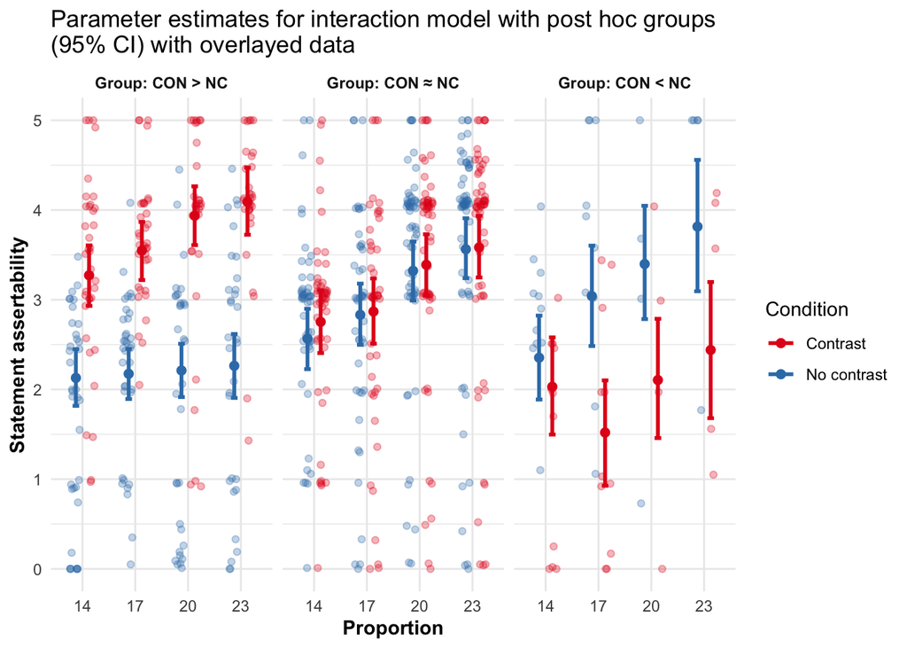

The figure indicates that for the CON > NC group, assertability in the Contrast condition was higher than in the No Contrast condition, and that there was a positive effect of Proportion in the Contrast cases. In this group, responses to the No Contrast condition are close to the theoretical expectations, but responses in the Contrast condition are still well below the theoretical expectations.

For the CON ≈ NC group, we find that assertability in the Contrast condition is very similar to assertability in the No Contrast condition, and in both cases Proportion has a similar positive effect on assertability.